# Analysis on harmful disasters in United States

Thiloshon Nagarajah

3/28/2017

## Synopsis

United States has a long history of facing deadliest and harmful weather histories. It is utmost important to analyse the various weather conditions and take measures to face those efficiently. So it makes sense to identify the most harmful or deadliest weather conditions and priotize the remedies accordingly. We have analyzed the weather data and found out 10 most deadliest conditions in terms of population health and economic consequensces. The Tornado related conditions have the highest impact on human health resulting in 5633 fatalities and 91346 injuries. The Flood has made more property damage worth of 144657709807 USD and Drought has created more impact on crops with worth of 13972566000 USD. The findings are covered below in depth.

## Processing

The data was read into the workspace with normal **read.csv()** function. The library needed were added.

```r
library(ggplot2)
strData <- read.csv("stormData.csv.bz2")
```

The read data was processed to make the proper value types, make the values consistant.

```r
strData$EVTYPE <- as.character(strData$EVTYPE)
strData$PROPDMGEXP<-as.factor(toupper(strData$PROPDMGEXP))
strData$CROPDMGEXP<-as.factor(toupper(strData$CROPDMGEXP))
```

The exact worth of damages were calculated from the “H”,“K”, “M”, “B” values.

```r
index <- c("","+", "-", "0", "1", "2", "3", "4", "5", "6", "7", "8", "?", "H", "K", "M", "B")
values <- c(1,1,1,1,1,1,1,1,1,1,1,1,1,100, 1000, 1000000, 1000000000)
strData$compensation <- values[match(strData$PROPDMGEXP, index)]
strData$compensationCrop <- values[match(strData$CROPDMGEXP, index)]

strData$propertyDamage<- (strData$PROPDMG*strData$compensation)/1000000
strData$cropDamage<- (strData$CROPDMG*strData$compensationCrop)/1000000
```

The top ten conditions of each type were found after aggregating the total values of each conditions.

```r
# Human - Fatality
setFatality <- aggregate(strData$FATALITIES, list(strData$EVTYPE), sum)
valFatality <- setFatality[order(setFatality$x, decreasing = TRUE),]
valFatality <- valFatality[1:10,]

# Human - Injury
setInjury <- aggregate(strData$INJURIES, list(strData$EVTYPE), sum)
valInjury <- setInjury[order(setInjury$x, decreasing = TRUE),]
valInjury <- valInjury[1:10,]

# Economy - Property
setProperty <- aggregate(strData$propertyDamage, list(strData$EVTYPE), sum)
valProperty <- setProperty[order(setProperty$x, decreasing = TRUE),]
valProperty <- valProperty[1:10,]

# Economy - Crop
setCrop <- aggregate(strData$cropDamage, list(strData$EVTYPE), sum)
valCrop <- setCrop[order(setCrop$x, decreasing = TRUE),]
valCrop <- valCrop[1:10,]
```

The graphs were drawn.

```r
p1 <- ggplot(valFatality) +
    geom_point(aes(y = valFatality$x, x = valFatality$Group.1), color = "Red") +
    theme(axis.text.x = element_text(angle = 90, hjust = 1)) +
    labs(title = "Top 10 deadliest events in terms of ") +
    xlab("Event") +
    ylab("Fatalities")

p2 <- ggplot(valInjury) +
    geom_point(aes(y = valInjury$x, x = valInjury$Group.1), color = "Blue") +
    theme(axis.text.x = element_text(angle = 90, hjust = 1)) +
    xlab("Event") +
    ylab("Injuries")+
    labs(title = "human Health")

p3 <- ggplot(valProperty) +
    geom_point(aes(y = valProperty$x, x = valProperty$Group.1), color = "Red") +
    theme(axis.text.x = element_text(angle = 90, hjust = 1)) +
    labs(title = "Top 10 deadliest events in terms ") +
    xlab("Event") +
    ylab("Property Damages in millions USD")

p4 <- ggplot(valCrop) +
    geom_point(aes(y = valCrop$x, x = valCrop$Group.1), color = "Blue") +
    theme(axis.text.x = element_text(angle = 90, hjust = 1)) +
    xlab("Event") +
    ylab("Crop Damages in millions USD")+
    labs(title = "of economy consequences ")
```

## results

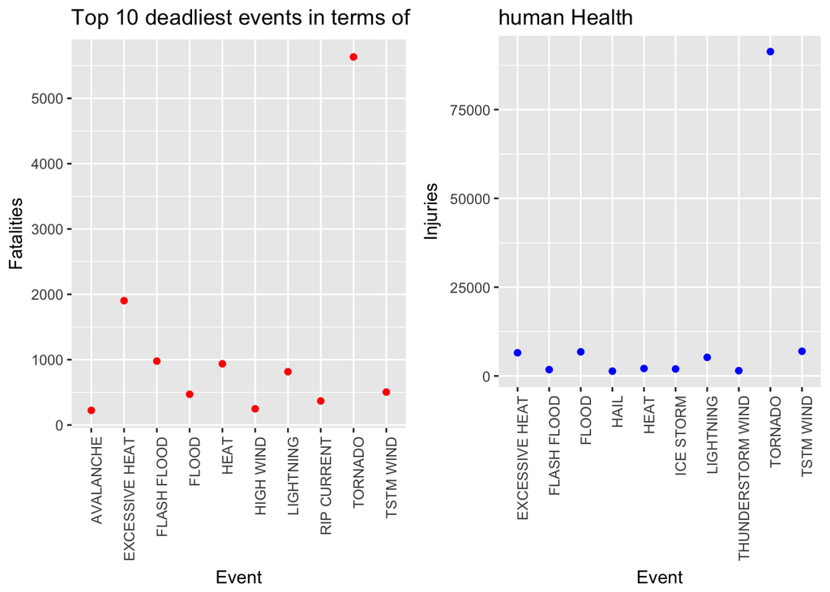

```r
library(gridExtra)
grid.arrange(p1, p2, ncol = 2)
```

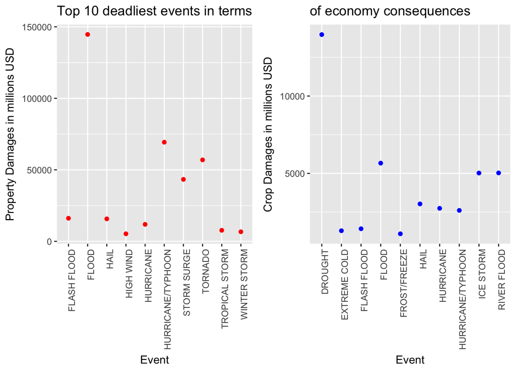

```r
grid.arrange(p3, p4, ncol = 2)
```